# Project 3 TSP using ACO

## Assignment 3

Names: Stephanie Saenz, Sofia Torres, Mia Marte.\ Last edited: 7-7-2023 \ Class CAP 4630 with Dr.Marques.

### Project Overview

In this assignment we will implement an evolutionary approach to solving the classical Traveling Salesman Problem (TSP) using Ant Colony Optimization(ACO) techniques in python.\ As we know, the TSP is known for finding the shortest route that salemsan can take to visit a set of cities exactly once and return to the starting city. By using ACO we are going to be able to improve the quality of solutiones obtained through the TSP, which can be efficient to tackle the TSP.

### Future Improvements

We were thinking of adding an advanced pherome using update strategies. For example, with the ACS system we can add an online/offline pheromone updates which can provide better convergence and solution quality. Where it wil explore alternative pherome updated rules, such as rank-based or global best-based updates to enhance the search process.

## Project Roles:

### Architect role - Stephanie Saenz .

The architect plays a crucial role in designing the overall structure and logic of the TSP using Ant Colony Optimization (ACO ) techniques.\ Logic Design: define the logic and mechanics. They need to determine how users wil handle inputs and alternating conditions. Class and Function Design: Design the classes and functions required for the software solution. Define functions that will use TSP and genetic algorithms.\ Overall Project Structure: plan the project's file structure, organize modules and scripts, and decide on a suitable approach for code organization and separation of concerns.\

### Developer role - Sofia Torres

The developer will implement the solution based on the design provided by the architect. Implementing Classes and Functions: The developer will write the code for the classes and functions defined by the architect. This includes creating the necessary data structures, implementing algorithms for solving the Traveling Salesman Problem, and managing the input and output of the program.\ Error Handling: The developer should handle potential errors and exceptions, ensuring that the program handles unexpected inputs or edge cases gracefully and provides appropriate feedback or error messages to the users.\ Unit Testing: The developer should write unit tests to ensure that each function and class work as intended. This will help catch any bugs or issues early in the development process and ensure the correctness of the solution for different test cases.\ Code Integration: The developer will integrate the individual components and functionalities developed by themselves and other team members, ensuring smooth interactions between different parts of the software solution for the Traveling Salesman Problem.\

### Reporter role - Mia Marte

The reporter is responsible for ensuring effective communication within the team and documenting the progress of the project. Team Coordination: The reporter should schedule regular meetings and discussions with the architect and developer to review progress, clarify requirements, and address any questions or issues that may arise.\ Progress Tracking: The reporter will keep track of the project's milestones, deadlines, and overall progress. They should regularly update the team on the status of each task and ensure that everyone is aware of their responsibilities.\ Documentation and Reporting: The reporter should maintain documentation of the project, including meeting notes, decisions made, and any changes or updates to the initial design. This documentation will help with future maintenance and troubleshooting.\ User Documentation: The reporter can also work on creating user documentation, such as a user manual or guide, to help users understand how to play the game and navigate its features.

## Answers to Questions:

#### How were the cities and distances represented (as a data structure)?

The cities are represented by a tuple (x, y) where x and y represent the coordinates of a city on a 2D plane. The distances on the other hand are represented using the Edge object, inside the edges list where it stores all the connections between cities.

#### How did you encode the solution space?

The solution space is encoded using a permutation of the cities. By using the get_distance() method of the Ant class, this will determine the total distance traveled in the tour by summing the distances of the edges between cities in the tour. The ACO technique uses multiple ants to explore the solution space simultaneously, where it also explores and refines the solution space by adjusting pheromone levels on the edges based on the tours generated by ants.

#### How did you handle the creation of the initial ant population?

We handled the initial ant population by using the colony_size parameter passsed to the constructor. Inside the constructor, there a list called ants and its purpose is to store the ant objects. This was created using a loop that runs the colony_size times so, each iteration of the loop creates a new instance of the ant class. To conclude, the initial ant population was handled by instantiating multiple ant objects and storing them in a list, while the size of the population was determined by a parameter.

#### How did you handle the updating of the pheromone trails?

We handled the update of pheromone trails by different ways, one of them is using the _max_min() method. This method was resposinble for updating the pheromone trails in the MaxMin mode. Every time there was an iteration of the ACO algorithm, each ant would constructs a tour and they would select the best tour (shorted distance) among all ants. By using this method, we made sure that the pheromone levels on the edges were adjusted based on the quality of tour. Another way that this was used was by using the _elitistst() method, which handles the updating of pheromone trails in the elitist mode. This method is used by making sure that the pheromone trails of the global best tour are reinforced by adding extra pheromone using the function _add_pheromone(). This will make sure that each ants constructs a tour and deposits pheromone on the edges based on the quality of its tour. Last final way, that we updated the pheromone trail is by using the _acs() method which is responsible for updating the pheromone trails. Every time there is an iteration of the ACO algorithm, each ant would construct a tour and deposit pheromone on the edges based on the quality of its tour; this is very similar to the _elitists() method. These three methods were used to update the pheromone trails level.

#### Which strategy(ies) did you use to compute the best solution?

We used the global_best_distance stratefy to compare the distance of its tour with the current best distance. Lets say that if an ant finds a tour with a shorter distance, this will update the best tour and the global best distance. This strategy ensures that the algorithm keeps the best solution found by any ant throughout the iterations. Another strategy that we used in the Elitist and MaxMin mode was the _add_pheromone() method, this method aims to guide the search toward the high-quality solutions discovered so far, and it helps improve the convergence of the algorithm. This algorithm will compute the best solution by comparing the distances of the tours generated by ants, which again will help ensure that the algorithm maintains the best solution found by ants.

#### Which stopping condition did you use? Why?

The stopping solution that we used, was mainly based on the number of iterations or steps defined by the steps parameter in the constructor of the SolveTSPUsingACO class. So the way it works is that we implemented a loop that will iterate for the specified number of steps, in each steps the ants would construct their tours, update the pheromone trails and potentially update the global best tour and eventually stop. However, the choice of the stopping condition depends on the specific problem, the desired solution quality and the time constraint. Although, with this implementation we used a fixed number of steps to ensure a consistent runtime for the algorithm.

#### What other parameters, design choices, initialization and configuration steps are relevant to your design and implementation?

One of the parameter that we used were the alpha and beta. Their job is to control the relative importance of the pheromone trail and heuristic information in the ants decision-making process. We also used the colony_size to determine the size of the ant colony. As for the design choices we used the ACO mode, this code supports the ACS, the Elitist and the MaxMin mode which were used to determine the output of our code. This method, used different strategies to determine the best tour. Lastly, for intialization steps and configuration we included the City initizalition, where citis are randomly generated with coordinates in the node list. We also added the Edge initialization, which calculcates the distance between cities using the Euclidean distance fomrula while storaging it on the edges list. To conclude, we added more parameters, design choices and initialization and configuration options that were not mention, but these were our important ones.

#### Which (simple) experiments have you run to observe the impact of different design decisions and parameter values? Post their results and your comments.

In our previous project we knew the parameters values had to be explicit in order to get the right position with the two players in the game. With this simple instance, we can relate this to the TSP problem using ACO because the parameters influenced the path of the algorithm. Not only that, we must keep in mind that the parameters in our case needed the graph, the progression and the final path to be explicit within their own function in order to work properly.

# Implementation:

*Below are some our classes and functions of our original code:*

- **'SolveTSPUsingACO**’: The primary class used to build the ACO algorithm for resolving the TSP is this one. It has the tools and features to set up and execute the algorithm.
- **‘Edge**’: In the TSP problem, this class represents an edge between two cities. It includes details like the weight (distance) of the edge, the quantity of pheromones on the edge, and the indices of the two cities (a and b).
- **‘Ant’**: In the ACO algorithm, this class stands in for an ant. Based on the number of pheromones on the edges and the heuristic data, each ant decides which city to visit next. Additionally, it records the distance traveled as well as the tour (a list of the cities it has visited).
- **‘_select_node’**: The next city the ant will visit is chosen by this method in the Ant class. Based on pheromone levels and heuristic data, it employs a roulette wheel selection process.
- **‘find_tour’**: By choosing the next city to visit until all towns have been visited, this method in the Ant class builds a whole tour.
- **‘get_distance’**: The overall distance covered throughout the ant’s trip is determined by this method in the Ant class.
- **‘_add_phermone’**: Based on a given tour and its distance, this method in the SolveTSPUsingACO class changes the pheromone levels on the edges.
- **‘_acs’, ‘_elitist’, ‘_max_min’**: These SolveTSPUsingACO class methods implement the Ant Colony System (ACS), Elitist Ant System, and Max-Min Ant System variant of the ACO algorithm. Each method manages the iteration logic and pheromone changes unique to the corresponding algorithm.
- **‘Run’**: The SolveTSPUsingACO class’s RunACO function is in charge of executing the ACO algorithm. Based on the input, it chooses the suitable algorithm mode and performs the required operations.
- **‘Plot’**: The SolveTSPUsingACO class contains a method that uses Matplotlib to show the optimal route determined by the algorithm. The cities are plotted, connected by lines, and the labels are shown.
- **‘**main**’** block: This block of code demonstrates how to create instances of the ‘SolveTSPUsingACO’ class with different algorithm modes, and it executed the ACO algorithm on randomly selected genes.

### Below is our source code for this project:

```
Started : ACS
Ended : ACS
Sequence : <- 9 - 1 - 5 - 21 - 23 - 11 - 4 - 3 - 18 - 7 - 12 - 14 - 2 - 16 - 19 - 17 - 22 - 13 - 6 - 8 - 25 - 15 - 10 - 24 - 20 ->
Total distance travelled to complete the tour : 1833.93
```

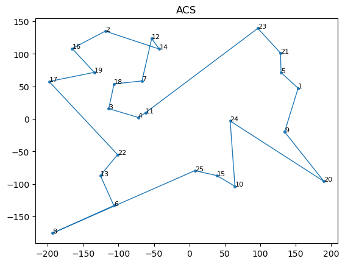

```
Started : Elitist
Ended : Elitist
Sequence : <- 8 - 6 - 13 - 22 - 4 - 11 - 7 - 18 - 19 - 16 - 2 - 12 - 14 - 23 - 21 - 5 - 1 - 9 - 24 - 15 - 10 - 20 - 25 - 3 - 17 ->
Total distance travelled to complete the tour : 1884.14
```

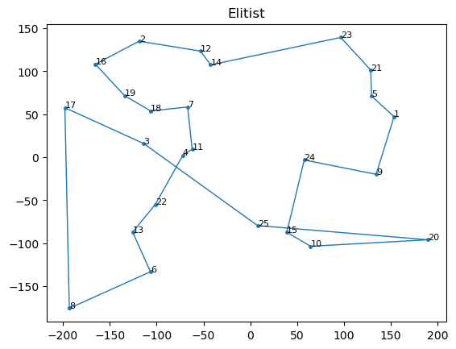

```
Started : MaxMin
Ended : MaxMin
Sequence : <- 18 - 3 - 4 - 11 - 24 - 25 - 15 - 10 - 20 - 9 - 1 - 5 - 21 - 23 - 7 - 14 - 12 - 2 - 16 - 19 - 17 - 22 - 13 - 6 - 8 ->
Total distance travelled to complete the tour : 1843.02
```

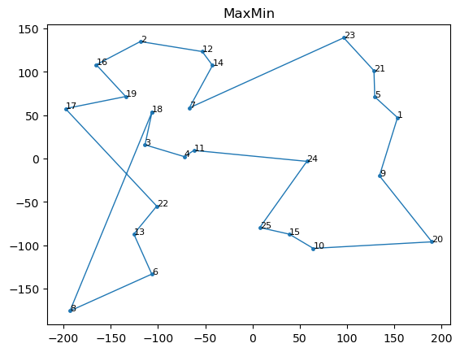

```python
import math
import random
from matplotlib import pyplot as plt


class SolveTSPUsingACO:
    class Edge:
        def __init__(self, a, b, weight, initial_pheromone):
            self.a = a
            self.b = b
            self.weight = weight
            self.pheromone = initial_pheromone


    class Ant:
        def __init__(self, alpha, beta, num_nodes, edges):
            """
            alpha -> parameter used to control the importance of the pheromone trail
            beta  -> parameter used to control the heuristic information during selection
            """
            self.alpha = alpha
            self.beta = beta
            self.num_nodes = num_nodes
            self.edges = edges
            self.tour = None
            self.distance = 0.0

        def _select_node(self):
            """
            Here, an ant would be selecting the next city depending on the distance
            to the next city, and the amount of pheromone on the path between
            the two cities.
            """
            roulette_wheel = 0.0
            unvisited_nodes = [node for node in range(self.num_nodes) if node not in self.tour]
            heuristic_total = 0.0
            for unvisited_node in unvisited_nodes:
                heuristic_total += self.edges[self.tour[-1]][unvisited_node].weight
            for unvisited_node in unvisited_nodes:
                roulette_wheel += pow(self.edges[self.tour[-1]][unvisited_node].pheromone, self.alpha) * \
                                  pow((heuristic_total / self.edges[self.tour[-1]][unvisited_node].weight), self.beta)
            random_value = random.uniform(0.0, roulette_wheel)
            wheel_position = 0.0
            for unvisited_node in unvisited_nodes:
                wheel_position += pow(self.edges[self.tour[-1]][unvisited_node].pheromone, self.alpha) * \
                                  pow((heuristic_total / self.edges[self.tour[-1]][unvisited_node].weight), self.beta)
                if wheel_position >= random_value:
                    return unvisited_node

        def find_tour(self):
            self.tour = [random.randint(0, self.num_nodes - 1)]
            while len(self.tour) < self.num_nodes:
                self.tour.append(self._select_node())
            return self.tour

        def get_distance(self):
            self.distance = 0.0
            for i in range(self.num_nodes):
                self.distance += self.edges[self.tour[i]][self.tour[(i + 1) % self.num_nodes]].weight
            return self.distance

    def __init__(self, mode='ACS', colony_size=10, elitist_weight=1.0, min_scaling_factor=0.001, alpha=1.0, beta=3.0,
                 rho=0.1, pheromone_deposit_weight=1.0, initial_pheromone=1.0, steps=100, nodes=None, labels=None):
        self.mode = mode
        self.colony_size = colony_size
        self.elitist_weight = elitist_weight
        self.min_scaling_factor = min_scaling_factor
        self.rho = rho
        self.pheromone_deposit_weight = pheromone_deposit_weight
        self.steps = steps
        self.num_nodes = len(nodes)
        self.nodes = nodes
        if labels is not None:
            self.labels = labels
        else:
            self.labels = range(1, self.num_nodes + 1)
        self.edges = [[None] * self.num_nodes for _ in range(self.num_nodes)]
        for i in range(self.num_nodes):
            for j in range(i + 1, self.num_nodes):
                self.edges[i][j] = self.edges[j][i] = self.Edge(i, j, math.sqrt(
                    pow(self.nodes[i][0] - self.nodes[j][0], 2.0) + pow(self.nodes[i][1] - self.nodes[j][1], 2.0)),
                                                                initial_pheromone)
        self.ants = [self.Ant(alpha, beta, self.num_nodes, self.edges) for _ in range(self.colony_size)]
        self.global_best_tour = None
        self.global_best_distance = float("inf")

    def _add_pheromone(self, tour, distance, weight=1.0):
        pheromone_to_add = self.pheromone_deposit_weight / distance
        for i in range(self.num_nodes):
            self.edges[tour[i]][tour[(i + 1) % self.num_nodes]].pheromone += weight * pheromone_to_add

    def _acs(self):
        for step in range(self.steps):
            for ant in self.ants:
                self._add_pheromone(ant.find_tour(), ant.get_distance())
                if ant.distance < self.global_best_distance:
                    self.global_best_tour = ant.tour
                    self.global_best_distance = ant.distance
            for i in range(self.num_nodes):
                for j in range(i + 1, self.num_nodes):
                    self.edges[i][j].pheromone *= (1.0 - self.rho)

        """
        In elitist ACO systems, either the best current, or global best ant,
        deposits extra pheromone during it's local pheromone update procedure.
        This encourages the colony to refine it's search around solutions
        which have a track record of being high quality. If all goes well,
        this should result in better search performance.
        """

    def _elitist(self):
        for step in range(self.steps):
            for ant in self.ants:
                self._add_pheromone(ant.find_tour(), ant.get_distance())
                if ant.distance < self.global_best_distance:
                    self.global_best_tour = ant.tour
                    self.global_best_distance = ant.distance
            self._add_pheromone(self.global_best_tour, self.global_best_distance, weight=self.elitist_weight)
            for i in range(self.num_nodes):
                for j in range(i + 1, self.num_nodes):
                    self.edges[i][j].pheromone *= (1.0 - self.rho)



        """
        The MaxMin algorithm is similar to the elitist ACO algorithm in that
        it gives preference to high ranking solutions.
        However, in MaxMin instead of simply giving extra weight to elite solutions,
        only the best current, or best global solution, is allowed to deposit a pheromone trail.
        """

    def _max_min(self):
        for step in range(self.steps):
            iteration_best_tour = None
            iteration_best_distance = float("inf")
            for ant in self.ants:
                ant.find_tour()
                if ant.get_distance() < iteration_best_distance:
                    iteration_best_tour = ant.tour
                    iteration_best_distance = ant.distance
            if float(step + 1) / float(self.steps) <= 0.75:
                self._add_pheromone(iteration_best_tour, iteration_best_distance)
                max_pheromone = self.pheromone_deposit_weight / iteration_best_distance
            else:
                if iteration_best_distance < self.global_best_distance:
                    self.global_best_tour = iteration_best_tour
                    self.global_best_distance = iteration_best_distance
                self._add_pheromone(self.global_best_tour, self.global_best_distance)
                max_pheromone = self.pheromone_deposit_weight / self.global_best_distance
            min_pheromone = max_pheromone * self.min_scaling_factor
            for i in range(self.num_nodes):
                for j in range(i + 1, self.num_nodes):
                    self.edges[i][j].pheromone *= (1.0 - self.rho)
                    if self.edges[i][j].pheromone > max_pheromone:
                        self.edges[i][j].pheromone = max_pheromone
                    elif self.edges[i][j].pheromone < min_pheromone:
                        self.edges[i][j].pheromone = min_pheromone

    def run(self):
        print('Started : {0}'.format(self.mode))
        if self.mode == 'ACS':
            self._acs()
        elif self.mode == 'Elitist':
            self._elitist()
        else:
            self._max_min()
        print('Ended : {0}'.format(self.mode))
        print('Sequence : <- {0} ->'.format(' - '.join(str(self.labels[i]) for i in self.global_best_tour)))
        print('Total distance travelled to complete the tour : {0}\n'.format(round(self.global_best_distance, 2)))

    def plot(self, line_width=1, point_radius=math.sqrt(2.0), annotation_size=8, dpi=120, save=True, name=None):
        x = [self.nodes[i][0] for i in self.global_best_tour]
        x.append(x[0])
        y = [self.nodes[i][1] for i in self.global_best_tour]
        y.append(y[0])
        plt.plot(x, y, linewidth=line_width)
        plt.scatter(x, y, s=math.pi * (point_radius ** 2.0))
        plt.title(self.mode)
        for i in self.global_best_tour:
            plt.annotate(self.labels[i], self.nodes[i], size=annotation_size)
        if save:
            if name is None:
                name = '{0}.png'.format(self.mode)
            plt.savefig(name, dpi=dpi)
        plt.show()
        plt.gcf().clear()


if __name__ == '__main__':
    _colony_size = 5
    _steps = 50
    _nodes = [(random.uniform(-200, 200), random.uniform(-200, 200)) for _ in range(0, 25)]
    acs = SolveTSPUsingACO(mode='ACS', colony_size=_colony_size, steps=_steps, nodes=_nodes)
    acs.run()
    acs.plot()
    elitist = SolveTSPUsingACO(mode='Elitist', colony_size=_colony_size, steps=_steps, nodes=_nodes)
    elitist.run()
    elitist.plot()
    max_min = SolveTSPUsingACO(mode='MaxMin', colony_size=_colony_size, steps=_steps, nodes=_nodes)
    max_min.run()
    max_min.plot()
```

##### by running the code above, you'll get a randomn output. However, below you can see the results to our code every time we ran it.

### Our Results:

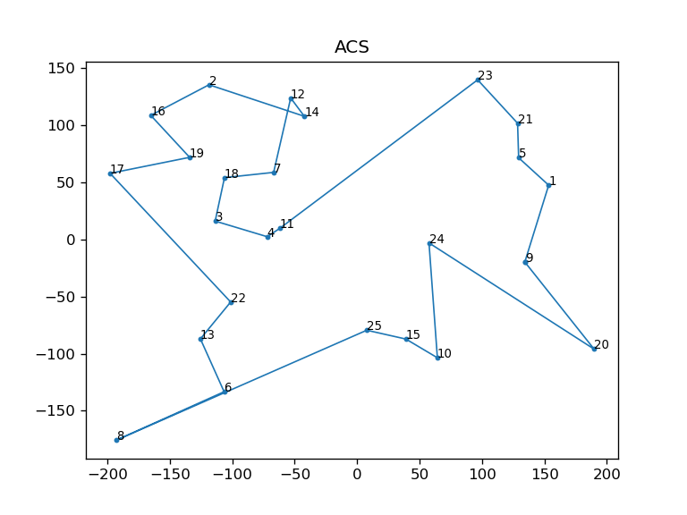

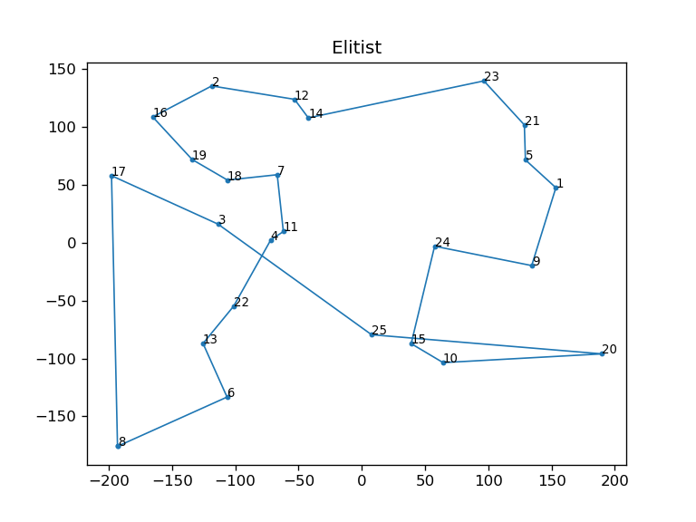

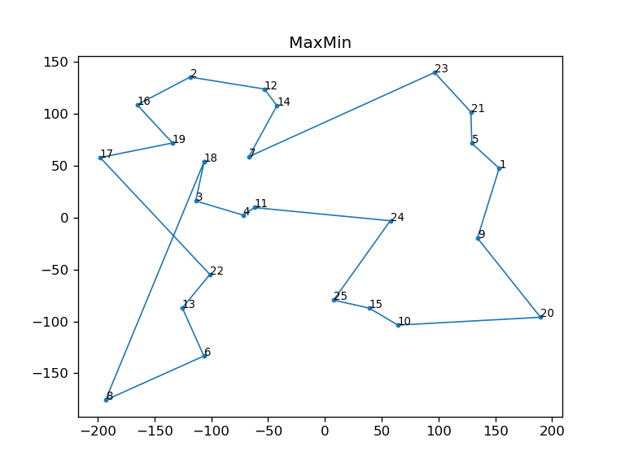

## References:

- https://github.com/rochakgupta/aco-tsp (“Solving Travelling Salesman Problem using Ant Colony Optimization”)
- Hurbans, R. (2020). In Grokking artificial intelligence algorithms. Manning Publications.
- https://www.youtube.com/watch?v=HW29067qVWk ('Jupyter Notebook Tutorial: Introduction, Setup, and Walkthrough')
- https://www.youtube.com/watch?v=Sk9QQUGMdY8('Solve the Traveling salesman problem (Genetic Algorithm, Ant Colony Optimization'))